# Evaluate Techniques Wifi Locationing

Marta Venegas Pardo

2/28/2022

# Descripción del proyecto

## Descripción

El proyecto se centra en el desarrollo de un sistema que se implementará en grandes campus industriales, en centros comerciales,.. con el fin de ayudar a las personas a navegar por un espacio interior y desconocido sin perderse.

Debemos investigar la posibilidad de usar “huellas dactilares wifi” para determinar la ubicación de una persona en espacios interiores (localización automática).

La toma de huellas WLAN utiliza las señales de múltiples puntos de acceso wifi dentro del edificio para determinar la ubicación, de manera análoga a cómo el GPS usa las señales satelitales.

La localización automática de usuarios consiste en estimar la posición del usuario (latitud, longitud y altitud) mediante el uso de un dispositivo electrónico, normalmente un teléfono móvil.

Sin embargo, la localización en interiores sigue siendo un problema abierto principalmente debido a la pérdida de señal GPS en entornos interiores. Aunque existen algunas tecnologías y metodologías de posicionamiento en interiores, esta base de datos se centra en las basadas en huellas dactilares WLAN (también conocidas como huellas dactilares WiFi).

## Objetivo: Ubicación en interiores

- El objetivo principal es la determinación de la posición física de una persona en un espacio interior de varios edificios mediante señales wifi.
- Variables objetivo: aquellas relacionadas con la posición del usuario, es decir, las coordenadas (latitud, longitud, piso) y el ID del edificio.

## Procedimiento

Se tratará de llevara cabo la localización de las personas mediante la creación de modelos de aprendizaje automático para ver cuál produce el mejor resultado.

Modelos:

- Regresión: latitud y longitud
- Clasificación: Piso e ID del edificio

El objetivo es estimar el edificio, el piso y las coordenadas (latitud y longitud) de las 1111 muestras incluidas en el conjunto de validación. Como también se incluyen los valores reales del edificio, planta y coordenadas, es posible determinar el error de localización.

# Lectura y descripción de los datos

## Descripción del conjunto de datos

Los datos han sido extraidos de la base de datos UJIIndoorLoc, que cubre tres edificios de la Universitat Jaume I en Castellón, Comunidad Valenciana, y éstos tienen 4 o 5 plantas, dependiendo del edificio y casi un total de 110.000m2.

Fue creado en 2013 a través de más de 20 usuarios diferentes y 25 dispositivos Android (algún usuario usó más de un dispositivo).

Existen 933 puntos de referencia en la base de datos

La base de datos consta de:

- 19937 registros de capacitación/referencia (archivo trainingData.csv)
- 1111 registros de validación/prueba (archivo validationData.csv)

Cada registro corresponde a una única medición y consta de 529 atributos contienen la huella digital WiFi WAP, las coordenadas donde se tomó y otra información útil como identificación del usuario o dispositivo móvil utilizado.

Cada huella WiFi se puede caracterizar por los puntos de acceso inalámbrico (WAP) detectados y la intensidad de la señal recibida (RSSI) correspondiente.

Los valores de intensidad se representan como valores enteros negativos que van desde -104dBm (señal extremadamente pobre) hasta 0dbM. Por tanto, mientras más cercano sea el valor a 0, mejor será la señal.

El valor positivo 100 se ha usado para indicar cuándo no se detectó señal en un WAP concreto, sin embargo, posteriormente transformaremos este valor

Durante la creación de la base de datos, se detectaron 520 WAP diferentes. Por lo tanto, la huella dactilar WiFi está compuesta por 520 valores de intensidad.

También se registra información sobre quién (usuario), cómo (dispositivo y versión de Android) y cuándo (marca temporal) se tomó la captura WiFi.

## Variables incluídas en el dataset

- WAP001-WAP520 (RSSI level): Valor de la intensidad de señal que llega al móvil desde cada punto de acceso inalámbrico WAP (Wireless Access Points) 1-520.
  - Rango de valores: -104-0
  - Unidad: decibelio-milivatio dBm. Se trata de una medida logarítmica de portencia en relación a un milivatio.
  - Un valor de 100 dBm indica que la señal no fué detectada **
  - Un valor a partir de -120 dBm indica que no se ha detectado señal
  - Mientras más cercano sea elvalor a 0, mejor será la señal
  - Nota: RSSI: Received Signal Strength Indicator
- Longitude: longitud, variable numérica, con un rango de valores: desde -7695.9387549299299000 hasta -7299.786516730871000
- Latitude: latitud, variable numérica, con un rango de valores: desde 4864745.7450159714 hasta 4865017.3646842018
- Floor: Planta dentro del edificio, variable categórica (0-4)
- BuildingID: Identidicador del edificio. Las medidas han sido tomadas en tres efidicios diferentes. Variable categórica (0-2)
  - Listado:
    - 0 ESTCE - TI
    - 1 ESTCE - TD
    - 2 ESTCE - TC
- SpaceID: Identificador del lugar donde se ha tomado la señal (oficina, pasillo o clase). Variable categórica (1-254)
- RelativePosition: Posición relativa con respecto al espacio. Variable categórica (1 - dentro, 2 - Fuera, delante de la puerta).
- UserID: Identificador del usuario, también encontramos la altura del usuario, ya que puede ser útil porque la posición espacial concreta del dispositivo tiene un impacto directo en los valores RSSI medidos. Variable categórica (0-18)
- PhoneID: Identificador del modelo Android. Variable categórica (0-24)
  - Listado:
    - 0 Celkon A27 4.0.4(6577) 0
    - 1 GT-I8160 2.3.6 8
    - 2 GT-I8160 4.1.2 0
    - 3 GT-I9100 4.0.4 5
    - 4 GT-I9300 4.1.2 0
    - 5 GT-I9505 4.2.2 0
    - 6 GT-S5360 2.3.6 7
    - 7 GT-S6500 2.3.6 14
    - 8 Galaxy Nexus 4.2.2 10
    - 9 Galaxy Nexus 4.3 0
    - 10 HTC Desire HD 2.3.5 18
    - 11 HTC One 4.1.2 15
    - 12 HTC One 4.2.2 0
    - 13 HTC Wildfire S 2.3.5 0,11
    - 14 LT22i 4.0.4 0,1,9,16
    - 15 LT22i 4.1.2 0
    - 16 LT26i 4.0.4 3
    - 17 M1005D 4.0.4 13
    - 18 MT11i 2.3.4 4
    - 19 Nexus 4 4.2.2 6
    - 20 Nexus 4 4.3 0
    - 21 Nexus S 4.1.2 0
    - 22 Orange Monte Carlo 2.3.5 17
    - 23 Transformer TF101 4.0.3 2
    - 24 bq Curie 4.1.1 12
- Timestamp: Hora en que se tomó la señal. (Unidad: UNIX)

## Extracción de los datos

A continuación veremos el primer registro de los datos:

```
## [1] 19937   529
```

| WAP001 | WAP520 | LONGITUDE | LATITUDE | FLOOR | BUILDINGID | SPACEID | RELATIVEPOSITION | USERID | PHONEID | TIMESTAMP |
| --- | --- | --- | --- | --- | --- | --- | --- | --- | --- | --- |
| 100 | 100 | -7541.2642999999225 | 4864920.7782000005 | 2 | 1 | 106 | 2 | 2 | 23 | 1371713733 |

La dimensión de los datos de entrenamiento, que son los que utilizaremos para tratar de modelar la intensidad de señal es la siguiente: 19937, 529 y la de los datos de validación de los modelos: 1111, 529, y ambas tienen las mismas variables.

# Preprocesado de datos

## Valores faltantes

Ya nos indicaron en la descripción que no había datos faltantes.

## Varianza de la intensidad de señal

El conjunto de datos contiene un gran número de variables, con un total de 529. Además, en el conjunto de las 520 variables predictoras, el valor predominante es el de la no detección de señal y esto hará que en muchos casos, la varianza de estas variables sea muy cercana a 0.

```
##     WAP001     WAP002     WAP003     WAP004     WAP005     WAP006     WAP007
##   34.41984   33.61862    0.00000    0.00000   74.22955  525.87157  932.77316
##     WAP008     WAP009     WAP010     WAP011     WAP012     WAP013     WAP014
## 1089.68678  918.39809  159.61910 3866.67406 3899.02404 2704.58498 2683.55152
##     WAP015     WAP016     WAP017     WAP018     WAP019     WAP020     WAP021
## 1657.40583 1667.28292  151.33827  159.31366  632.13926  589.13762   69.88362
##     WAP022     WAP023     WAP024     WAP025     WAP026     WAP027     WAP028
##   69.68916 1194.36803 1201.60358  972.26867 1009.55130 1192.39982 1232.70076
##     WAP029     WAP030     WAP031     WAP032     WAP033     WAP034     WAP035
## 2110.51656 2192.25669  905.24984  901.65521 2163.53163 2154.68215 2570.55322
##     WAP036     WAP037     WAP038     WAP039     WAP040     WAP041     WAP042
## 2573.96359 1343.09959 1112.20124 2071.66555 2121.08956 2385.91492 2417.70411
##     WAP043     WAP044     WAP045     WAP046     WAP047     WAP048     WAP049
## 1664.02093 1709.59168 1198.96011 1306.72129 2005.76006 2021.79010  605.27904
##     WAP050     WAP051     WAP052     WAP053     WAP054     WAP055     WAP056
##  663.84812 3034.19366 2981.72209 1525.47187 1567.33593   57.21520   60.56970
##     WAP057     WAP058     WAP059     WAP060     WAP061     WAP062     WAP063
##  806.99465  865.10188 3105.36170 3536.33709 5428.29242 5658.20884 4645.41407
##     WAP064     WAP065     WAP066     WAP067     WAP068     WAP069     WAP070
## 4683.15689 5145.32687 5326.53015 2595.68560 2903.95374 5466.19685 5579.15693
##     WAP071     WAP072     WAP073     WAP074     WAP075     WAP076     WAP077
##  287.40246  314.21769 4533.73283 4597.30156 1259.36574 1273.78543 5737.89672
##     WAP078     WAP079     WAP080     WAP081     WAP082     WAP083     WAP084
## 5842.68808    1.92687 1422.86604 1452.72078 4122.83212 4150.38072 4915.37279
##     WAP085     WAP086     WAP087     WAP088     WAP089     WAP090     WAP091
## 4806.57442   70.17892 6040.96059 1062.51634 1174.67518 1575.88070 1590.23232
##     WAP092     WAP093     WAP094     WAP095     WAP096     WAP097     WAP098
##    0.00000    0.00000    0.00000    0.00000 3279.16372 3310.72539 3546.13468
##     WAP099     WAP100
## 3465.97113   32.61569
```

Nos planteamos ahora lo siguiente, ¿cuándo considerar una varianza muy pequeña?

Eliminar WAPS es eliminar zonas de *detección*, pero a la hora del modelado hará que tengamos menos errores y por tanto, mayor fiabilidad en las métricas.

- Varianzas próximas a 0

Esto indicaría que existen zonas de los edificios que están poco cubiertas y por tanto, que se ha registrado conexión en muy pocas ocasiones y la mayoría de las veces se trata de registros de no detección. Esas zonas están muy poco transitadas y por ello, es necesario eliminar estas variables, ya que podrían introducir ruido.

- Varianza igual a 0

Para aquellas variables donde la varianza es nula (no es una variable, sino una constante) o con un valor menor que el umbral, optaremos por eliminarlas de nuestro conjunto de datos para así reducir el número de variables.

Si la varianza de un WAP es nula, eso indicaría que no se pasa por ningún área de influencia de ese WAP, es decir, nadie ha pasado por ahí y hay un área que no está cubierta. Sin embargo, no podemos saber de que área se trata ya que no sabemos donde están ubicados los diferentes WAPs. Es necesario eliminar éstas variables ya que al haber partes del edificio que no registran señal, no aportan información y por tanto nuestro modelo no sería del todo adecuado.

En nuestro conjunto de datos, hay un total de 55 WAPs que tienen varianza 0 de los 520 existentes, y son las siguientes mostradas a continuación:

```
## WAP003 WAP004 WAP092 WAP093 WAP094 WAP095 WAP152 WAP158 WAP159 WAP160 WAP215
##      3      4     92     93     94     95    152    158    159    160    215
## WAP217 WAP226 WAP227 WAP238 WAP239 WAP240 WAP241 WAP242 WAP243 WAP244 WAP245
##    217    226    227    238    239    240    241    242    243    244    245
## WAP246 WAP247 WAP254 WAP293 WAP296 WAP301 WAP303 WAP304 WAP307 WAP333 WAP349
##    246    247    254    293    296    301    303    304    307    333    349
## WAP353 WAP360 WAP365 WAP416 WAP419 WAP423 WAP429 WAP433 WAP438 WAP441 WAP442
##    353    360    365    416    419    423    429    433    438    441    442
## WAP444 WAP445 WAP451 WAP458 WAP482 WAP485 WAP487 WAP488 WAP491 WAP497 WAP520
##    444    445    451    458    482    485    487    488    491    497    520
```

## Duplicados

Existen un total de 637 registros duplicados (idénticos) y supone un 3.2 % del total de datos, por lo que al ser un porcentaje tan bajo, las instancias serán eliminadas ya que podrían influir en nuestro análisis y modelado posterior.

Nota: En esta primera fase del tratamiento, hemos considerado que dos o más filas están duplicadas si estaban duplicadas en su totalidad, es decir, dos o más filas filas con los mismos atributos, no solo de identificación, sino también la misma marca temporal e intensidad de señal. Las 529 variables eran idénticas para estos registros.

Trás este procedimiento, obtenemos un conjunto de datos con las siguientes dimensiones: 19300, 399

A continuación, trás haber procedido a eliminar aquellas filas que estaban duplicadas en su totalidad, vamos a centrarnos en buscar registros duplicados considerando por éstos aquellas instancias que hayan sido registrados por el mismo individuo en la misma fecha (día y hora) y con el mismo teléfono móvil.

Encontramos un total de 5064 registros tomados por el mismo usuario con el mismo dispositivo y con la misma marca horaria. Esto supone un 26.24 % del total de registros, que es un porcentaje alto.

Los registros duplicados, y más un número tan elevado respecto del total de número de instancias podrían influir en los resultados de los modelos predictivos que vayamos a construir, y por tanto influiría directamente en el resultado que obtendremos de nuestro análisis.

¿Qué hacer y qué implicaría quitarlos?

Vamos a optar por eliminar estos registros duplicados, ya que podrían tratarse de registros erróneos en la toma de datos y que podrían llevarnos a construir modelos predictivos de menor calidad y que no saquen el mayor partido a los datos disponibles.

Eliminar estos registros implica perder información pero ganar consistencia en los datos y por tanto, en los resultados.

Por tanto, ahora tenemos un conjunto de datos con las siguientes dimensiones: 14236, 399

## Transformación de variables

En este apartado, transformaremos las variables para que tengan el formato y/o unidad oportunos para su posterior estudio.

### Categorización

Debemos categorizar las variables oportunas, como aquellas correspondientes a ID, posición relativa y planta.

Las variables latitud y longitud deben tener formato numérico, no de factor.

```
## 'data.frame':    14236 obs. of  10 variables:
##  $ WAP518          : int  100 100 100 100 100 100 100 100 100 100 ...
##  $ LONGITUDE       : num  489 480 441 453 553 468 441 462 499 421 ...
##  $ LATITUDE        : num  514 553 598 551 644 576 598 528 426 593 ...
##  $ FLOOR           : Factor w/ 5 levels "0","1","2","3",..: 3 3 3 3 1 3 3 3 3 3 ...
##  $ BUILDINGID      : Factor w/ 3 levels "0","1","2": 2 2 2 2 1 2 2 2 2 2 ...
##  $ SPACEID         : Factor w/ 123 levels "1","2","3","4",..: 31 31 28 27 47 30 28 26 37 28 ...
##  $ RELATIVEPOSITION: Factor w/ 2 levels "1","2": 2 2 2 2 2 2 2 2 2 1 ...
##  $ USERID          : Factor w/ 18 levels "1","2","3","4",..: 2 2 2 2 11 2 2 2 2 2 ...
##  $ PHONEID         : Factor w/ 16 levels "1","3","6","7",..: 15 15 15 15 8 15 15 15 15 15 ...
##  $ TIMESTAMP       : int  1371713733 1371713691 1371714095 1371713807 1369909710 1371713841 1371713883 1371713775 1371714307 1371714128 ...
```

### Reformateo de la no detección de señal

El valor de intensidad de señal mínimo registrado ha sido de -104 dBm, por tanto, optaremos por considerar que el valor de la no cobertura para la no conexión es de -120 dBm.

Realizamos la transformación y mostramos unos cuantos registros para su visualización.

```
##   WAP001 WAP002 WAP005 WAP006 WAP007 WAP008 WAP517 WAP518 LONGITUDE LATITUDE
## 1   -120   -120   -120   -120   -120   -120   -120    100       489      514
## 2   -120   -120   -120   -120   -120   -120   -120    100       480      553
## 3   -120   -120   -120   -120   -120    -97   -120    100       441      598
##   FLOOR BUILDINGID SPACEID RELATIVEPOSITION USERID PHONEID  TIMESTAMP
## 1     2          1     106                2      2      23 1371713733
## 2     2          1     106                2      2      23 1371713691
## 3     2          1     103                2      2      23 1371714095
```

### Formato horario

Además, tenemos que transformar la variable Timestamp a formato horario.

### Creación de nuevas variables

Es interesante conocer para cada instancia registrada por un usuario, cual es el WAP que tiene la mayor intensidad de señal.

- SeñalMax: valor de la intensidad de señal máxima registrada para cada instancia
- Señal min: valor de la intensidad mínima de señal registrada para cada instancia
- NumWAP_Detectados: Para cada registro, se va a recoger el número de WAPS detectados

El conjunto de datos tiene las siguientes dimensiones:

- Número de filas: 14236
- Número de columnas 408 de las cuales 389 corresponden a la intensidad de señal detectada

Vamos a estudiar con detenimiento el número de WAPS detectados, ya que es fundamental tener en cuenta que hay 389 variables WAP y lo mas probable es que la mayoría de estos valores correspondan a la no detección de señal.

- Valor medio, mediano y quartiles:

```
##    Min. 1st Qu.  Median    Mean 3rd Qu.    Max.
##    0.00   13.00   16.00   17.58   21.00   51.00
```

En el 50% del número total de registros se ha detectado señal con un total de 16 WAPS o menos al mismo tiempo.

- Deciles:

```
##   0%  10%  20%  30%  40%  50%  60%  70%  80%  90% 100%
##    0    9   12   14   15   16   18   20   23   28   51
```

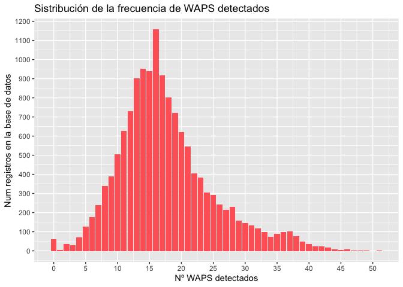

Vemos como algunas mediciones no han detectado ningún punto de acceso y el valor máximo de puntos de acceso detectados es de 51 WAPS en total. Esto indicaría que el resto de los 338 valores de la huella digital indican la no detección, es decir, conexión nula. Es decir, si el 90% de las mediciones han detectado únicamente 28 puntos de acceso o menos, la mayoría de los valores de nuestra base de datos son nulos.

En primer lugar, eliminamos aquellas filas que no hayan registrado intensidad de señal con ningún WAP, ya que esto significa que a esa zona no llega conexión alguna. Se trata de un total de 62 registros de los usuarios.

Debemos reducir el número de valores nulos en nuestra base datos y para ello, haremos lo siguiente: seleccionar únicamente aquellos WAPs con los que se haya registrado una intensidad de señal mayor, haciendo uso de la nueva variable llamada MaxSenal, que indica cual ha sido la máxima intensidad de señal registrada en cada medición.

```
## [1] 39
```

## Conjunto de datos trás el data cleaning

A continuación mostraremos el formato de las variables del conjunto de datos final, con una breve visualización de las mismas

```
## 'data.frame':    14174 obs. of  20 variables:
##  $ WAP001           : num  -120 -120 -120 -120 -120 -120 -120 -120 -120 -120 ...
##  $ WAP518           : int  100 100 100 100 100 100 100 100 100 100 ...
##  $ LONGITUDE        : num  489 480 441 453 468 441 462 499 421 464 ...
##  $ LATITUDE         : num  514 553 598 551 576 598 528 426 593 605 ...
##  $ FLOOR            : Factor w/ 5 levels "0","1","2","3",..: 3 3 3 3 3 3 3 3 3 3 ...
##  $ BUILDINGID       : Factor w/ 3 levels "0","1","2": 2 2 2 2 2 2 2 2 2 2 ...
##  $ SPACEID          : Factor w/ 123 levels "1","2","3","4",..: 31 31 28 27 30 28 26 37 28 29 ...
##  $ RELATIVEPOSITION : Factor w/ 2 levels "1","2": 2 2 2 2 2 2 2 2 1 1 ...
##  $ USERID           : Factor w/ 18 levels "1","2","3","4",..: 2 2 2 2 2 2 2 2 2 2 ...
##  $ PHONEID          : Factor w/ 16 levels "1","3","6","7",..: 15 15 15 15 15 15 15 15 15 15 ...
##  $ TIMESTAMP        : POSIXct, format: "2013-06-20 07:35:33" "2013-06-20 07:34:51" ...
##  $ year             : num  2013 2013 2013 2013 2013 ...
##  $ month            : Factor w/ 2 levels "5","6": 2 2 2 2 2 2 2 2 2 2 ...
##  $ day              : Factor w/ 6 levels "4","10","12",..: 4 4 4 4 4 4 4 4 4 4 ...
##  $ hour             : Factor w/ 12 levels "6","7","8","9",..: 2 2 2 2 2 2 2 2 2 2 ...
##  $ week             : Factor w/ 4 levels "22","23","24",..: 4 4 4 4 4 4 4 4 4 4 ...
##  $ weekday          : Factor w/ 5 levels "1","2","3","4",..: 4 4 4 4 4 4 4 4 4 4 ...
##  $ MaxSenal         : num  -53 -46 -61 -55 -55 -65 -62 -46 -69 -80 ...
##  $ MinSenal         : num  -95 -96 -98 -92 -98 -97 -96 -96 -95 -98 ...
##  $ NumWAP_Detectados: int  17 16 15 16 15 17 16 17 11 17 ...
```

|  | WAP001 | WAP002 | WAP005 | WAP006 | WAP007 | WAP008 |
| --- | --- | --- | --- | --- | --- | --- |
| 1 | -120 | -120 | -120 | -120 | -120 | -120 |
| 2 | -120 | -120 | -120 | -120 | -120 | -120 |
| 3 | -120 | -120 | -120 | -120 | -120 | -97 |
| 4 | -120 | -120 | -120 | -120 | -120 | -120 |
| 5 | -120 | -120 | -120 | -120 | -120 | -120 |
| 6 | -120 | -120 | -120 | -120 | -120 | -120 |
| 7 | -120 | -120 | -120 | -120 | -120 | -120 |
| 8 | -120 | -120 | -120 | -120 | -120 | -120 |
| 9 | -120 | -120 | -120 | -120 | -120 | -120 |
| 10 | -120 | -120 | -120 | -120 | -120 | -83 |

[output cut: 14164 more lines]

Por último, guardamos los datos ya preparados para el análisis en un archivo tipo *.RData* llamado *TrainingDataCleaned.RData*